# loan_prediction

# Justification: In the next code block, I will explore categorical features relating to applicants loan information and then deal with their missing values. In the end I will discard some features have little impact on the prediction. Specific reasons are provided in the comments adjacent to the corresponding code.

```r
#Let me then explore the categorical data
loan_categorical_data <- historical_data[,c(feature_loan_categorical,target)]

#check the NA value
# only feature conforming_loan_limit have 479 NA values
print(sum(is.na(loan_categorical_data$derived_loan_product_type)))
```

```
## [1] 0
```

```r
print(sum(is.na(loan_categorical_data$derived_dwelling_category)))
```

```
## [1] 0
```

```r
print(sum(is.na(loan_categorical_data$conforming_loan_limit))) #479
```

```
## [1] 479
```

```r
print(sum(is.na(loan_categorical_data$preapproval)))
```

```
## [1] 0
```

```r
print(sum(is.na(loan_categorical_data$loan_type)))
```

```
## [1] 0
```

```r
print(sum(is.na(loan_categorical_data$loan_purpose)))
```

```
## [1] 0
```

```r
print(sum(is.na(loan_categorical_data$lien_status)))
```

```
## [1] 0
```

```r
print(sum(is.na(loan_categorical_data$reverse_mortgage)))
```

```
## [1] 0
```

```r
print(sum(is.na(loan_categorical_data$open.end_line_of_credit)))
```

```
## [1] 0
```

```r
print(sum(is.na(loan_categorical_data$business_or_commercial_purpose)))
```

```
## [1] 0
```

```r
print(sum(is.na(loan_categorical_data$hoepa_status)))
```

```
## [1] 0
```

```r
print(sum(is.na(loan_categorical_data$negative_amortization)))
```

```
## [1] 0
```

```r
print(sum(is.na(loan_categorical_data$interest_only_payment)))
```

```
## [1] 0
```

```r
print(sum(is.na(loan_categorical_data$balloon_payment)))
```

```
## [1] 0
```

```r
print(sum(is.na(loan_categorical_data$other_nonamortizing_features)))
```

```
## [1] 0
```

```r
print(sum(is.na(loan_categorical_data$construction_method)))
```

```
## [1] 0
```

```r
print(sum(is.na(loan_categorical_data$occupancy_type)))
```

```
## [1] 0
```

```r
print(sum(is.na(loan_categorical_data$manufactured_home_secured_property_type)))
```

```
## [1] 0
```

```r
print(sum(is.na(loan_categorical_data$manufactured_home_land_property_interest)))
```

```
## [1] 0
```

```r
#From the description of conforming_loan_limit in CFPB's website, I found that NA values in this feature is also a class meaning Not Applicable, so I will fill NA with "NA"
loan_categorical_data$conforming_loan_limit <-ifelse(is.na(loan_categorical_data$conforming_loan_limit),
         "NA",
         loan_categorical_data$conforming_loan_limit)

#These categorical features just contain only a few classes, which allow to apply random forest.
length(unique(loan_categorical_data$derived_loan_product_type))
```

```
## [1] 7
```

```r
length(unique(loan_categorical_data$derived_dwelling_category))
```

```
## [1] 4
```

```r
length(unique(loan_categorical_data$conforming_loan_limit))
```

```
## [1] 4
```

```r
length(unique(loan_categorical_data$preapproval))
```

```
## [1] 2
```

```r
length(unique(loan_categorical_data$loan_type))
```

```
## [1] 4
```

```r
length(unique(loan_categorical_data$loan_purpose))
```

```
## [1] 6
```

```r
length(unique(loan_categorical_data$lien_status))
```

```
## [1] 2
```

```r
length(unique(loan_categorical_data$reverse_mortgage))
```

```
## [1] 3
```

```r
length(unique(loan_categorical_data$open.end_line_of_credit))
```

```
## [1] 3
```

```r
length(unique(loan_categorical_data$business_or_commercial_purpose))
```

```
## [1] 3
```

```r
length(unique(loan_categorical_data$hoepa_status))
```

```
## [1] 3
```

```r
length(unique(loan_categorical_data$negative_amortization))
```

```
## [1] 3
```

```r
length(unique(loan_categorical_data$interest_only_payment))
```

```
## [1] 3
```

```r
length(unique(loan_categorical_data$balloon_payment))
```

```
## [1] 3
```

```r
length(unique(loan_categorical_data$other_nonamortizing_features))
```

```
## [1] 3
```

```r
length(unique(loan_categorical_data$construction_method))
```

```
## [1] 2
```

```r
length(unique(loan_categorical_data$occupancy_type))
```

```
## [1] 3
```

```r
length(unique(loan_categorical_data$manufactured_home_secured_property_type))
```

```
## [1] 4
```

```r
length(unique(loan_categorical_data$manufactured_home_land_property_interest))
```

```
## [1] 6
```

```r
#Check if the feature has too direct relationship with target, which may cause data leakage.
##if the feature derived_loan_product_type = FSA/RHS:Subordinate Lien, all target values will be 1. But this only cover 1 instance and will not have a significant impact on the model
loan_categorical_data |>
group_by(derived_loan_product_type,action_taken) |>
summarize(n = n())
```

```
## # A tibble: 13 × 3
## # Groups:   derived_loan_product_type [7]
##    derived_loan_product_type     action_taken      n
##    <chr>                                <int>  <int>
##  1 Conventional:First Lien                  1 178125
##  2 Conventional:First Lien                  3  41169
##  3 Conventional:Subordinate Lien            1  52031
##  4 Conventional:Subordinate Lien            3  28959
##  5 FHA:First Lien                           1  34238
##  6 FHA:First Lien                           3   8095
##  7 FHA:Subordinate Lien                     1    115
##  8 FHA:Subordinate Lien                     3     67
##  9 FSA/RHS:First Lien                       1   3816
## 10 FSA/RHS:First Lien                       3    475
## 11 FSA/RHS:Subordinate Lien                 1      1
## 12 VA:First Lien                            1  13196
## 13 VA:First Lien                            3   3436
```

```r
loan_categorical_data |>
group_by(derived_dwelling_category,action_taken) |>
summarize(n = n())
```

```
## # A tibble: 8 × 3
## # Groups:   derived_dwelling_category [4]
##   derived_dwelling_category              action_taken      n
##   <chr>                                         <int>  <int>
## 1 Multifamily:Manufactured                          1      9
## 2 Multifamily:Manufactured                          3      3
## 3 Multifamily:Site-Built                            1    383
## 4 Multifamily:Site-Built                            3     84
## 5 Single Family (1-4 Units):Manufactured            1   3454
## 6 Single Family (1-4 Units):Manufactured            3   3196
## 7 Single Family (1-4 Units):Site-Built              1 277676
## 8 Single Family (1-4 Units):Site-Built              3  78918
```

```r
loan_categorical_data |>
group_by(conforming_loan_limit,action_taken) |>
summarize(n = n())
```

```
## # A tibble: 8 × 3
## # Groups:   conforming_loan_limit [4]
##   conforming_loan_limit action_taken      n
##   <chr>                        <int>  <int>
## 1 C                                1 273336
## 2 C                                3  80334
## 3 NA                               1    392
## 4 NA                               3     87
## 5 NC                               1   7787
## 6 NC                               3   1774
## 7 U                                1      7
## 8 U                                3      6
```

```r
#if the feature preapproval = 1, all target values will be 1. But this only cover 4962 instances and will not have a significant impact on the model
loan_categorical_data |>
group_by(preapproval,action_taken) |>
summarize(n = n())
```

```
## # A tibble: 3 × 3
## # Groups:   preapproval [2]
##   preapproval action_taken      n
##         <int>        <int>  <int>
## 1           1            1   4962
## 2           2            1 276560
## 3           2            3  82201
```

```r
loan_categorical_data |>
group_by(loan_type,action_taken) |>
summarize(n = n())
```

```
## # A tibble: 8 × 3
## # Groups:   loan_type [4]
##   loan_type action_taken      n
##       <int>        <int>  <int>
## 1         1            1 230156
## 2         1            3  70128
## 3         2            1  34353
## 4         2            3   8162
## 5         3            1  13196
## 6         3            3   3436
## 7         4            1   3817
## 8         4            3    475
```

```r
loan_categorical_data |>
group_by(loan_purpose,action_taken) |>
summarize(n = n())
```

```
## # A tibble: 12 × 3
## # Groups:   loan_purpose [6]
##    loan_purpose action_taken      n
##           <int>        <int>  <int>
##  1            1            1 127244
##  2            1            3  14555
##  3            2            1  29967
##  4            2            3  18916
##  5            4            1  22030
##  6            4            3  15680
##  7            5            1    360
##  8            5            3     27
##  9           31            1  68945
## 10           31            3  20066
## 11           32            1  32976
## 12           32            3  12957
```

```r
loan_categorical_data |>
group_by(lien_status,action_taken) |>
summarize(n = n())
```

```
## # A tibble: 4 × 3
## # Groups:   lien_status [2]
##   lien_status action_taken      n
##         <int>        <int>  <int>
## 1           1            1 229375
## 2           1            3  53175
## 3           2            1  52147
## 4           2            3  29026
```

```r
loan_categorical_data |>
group_by(reverse_mortgage,action_taken) |>
summarize(n = n())
```

```
## # A tibble: 6 × 3
## # Groups:   reverse_mortgage [3]
##   reverse_mortgage action_taken      n
##              <int>        <int>  <int>
## 1                1            1    717
## 2                1            3    238
## 3                2            1 267437
## 4                2            3  79666
## 5             1111            1  13368
## 6             1111            3   2297
```

```r
loan_categorical_data |>
group_by(open.end_line_of_credit,action_taken) |>
summarize(n = n())
```

```
## # A tibble: 6 × 3
## # Groups:   open.end_line_of_credit [3]
##   open.end_line_of_credit action_taken      n
##                     <int>        <int>  <int>
## 1                       1            1  56224
## 2                       1            3  32520
## 3                       2            1 211930
## 4                       2            3  47384
## 5                    1111            1  13368
## 6                    1111            3   2297
```

```r
loan_categorical_data |>
group_by(business_or_commercial_purpose,action_taken) |>
summarize(n = n())
```

```
## # A tibble: 6 × 3
## # Groups:   business_or_commercial_purpose [3]
##   business_or_commercial_purpose action_taken      n
##                            <int>        <int>  <int>
## 1                              1            1   6063
## 2                              1            3   1530
## 3                              2            1 262010
## 4                              2            3  78343
## 5                           1111            1  13449
## 6                           1111            3   2328
```

```r
#if the feature hoepa_status = 1 or 2, all target values will be 1. This involves about 260000 instances. It has too direct relationship with target. I will discard it in order to avoid overfitting.
loan_categorical_data |>
group_by(hoepa_status,action_taken) |>
summarize(n = n())
```

```
## # A tibble: 4 × 3
## # Groups:   hoepa_status [3]
##   hoepa_status action_taken      n
##          <int>        <int>  <int>
## 1            1            1    145
## 2            2            1 259274
## 3            3            1  22103
## 4            3            3  82201
```

```r
feature_discard <- c(feature_discard,c("hoepa_status"))

loan_categorical_data |>
group_by(negative_amortization,action_taken) |>
summarize(n = n())
```

```
## # A tibble: 6 × 3
## # Groups:   negative_amortization [3]
##   negative_amortization action_taken      n
##                   <int>        <int>  <int>
## 1                     1            1     14
## 2                     1            3      1
## 3                     2            1 268143
## 4                     2            3  79903
## 5                  1111            1  13365
## 6                  1111            3   2297
```

```r
loan_categorical_data |>
group_by(interest_only_payment,action_taken) |>
summarize(n = n())
```

```
## # A tibble: 6 × 3
## # Groups:   interest_only_payment [3]
##   interest_only_payment action_taken      n
##                   <int>        <int>  <int>
## 1                     1            1  34285
## 2                     1            3  15815
## 3                     2            1 233872
## 4                     2            3  64089
## 5                  1111            1  13365
## 6                  1111            3   2297
```

```r
loan_categorical_data |>
group_by(balloon_payment,action_taken) |>
summarize(n = n())
```

```
## # A tibble: 6 × 3
## # Groups:   balloon_payment [3]
##   balloon_payment action_taken      n
##             <int>        <int>  <int>
## 1               1            1   5656
## 2               1            3   2069
## 3               2            1 262501
## 4               2            3  77835
## 5            1111            1  13365
## 6            1111            3   2297
```

```r
loan_categorical_data |>
group_by(other_nonamortizing_features,action_taken) |>
summarize(n = n())
```

```
## # A tibble: 6 × 3
## # Groups:   other_nonamortizing_features [3]
##   other_nonamortizing_features action_taken      n
##                          <int>        <int>  <int>
## 1                            1            1    642
## 2                            1            3    778
## 3                            2            1 267515
## 4                            2            3  79126
## 5                         1111            1  13365
## 6                         1111            3   2297
```

```r
loan_categorical_data |>
group_by(construction_method,action_taken) |>
summarize(n = n())
```

```
## # A tibble: 4 × 3
## # Groups:   construction_method [2]
##   construction_method action_taken      n
##                 <int>        <int>  <int>
## 1                   1            1 278059
## 2                   1            3  79002
## 3                   2            1   3463
## 4                   2            3   3199
```

```r
loan_categorical_data |>
group_by(occupancy_type,action_taken) |>
summarize(n = n())
```

```
## # A tibble: 6 × 3
## # Groups:   occupancy_type [3]
##   occupancy_type action_taken      n
##            <int>        <int>  <int>
## 1              1            1 265004
## 2              1            3  76614
## 3              2            1   4280
## 4              2            3   1687
## 5              3            1  12238
## 6              3            3   3900
```

```r
loan_categorical_data |>
group_by(manufactured_home_secured_property_type,action_taken) |>
summarize(n = n())
```

```
## You can override using the `.groups` argument.
```

```
## # A tibble: 8 × 3
## # Groups:   manufactured_home_secured_property_type [4]
##   manufactured_home_secured_property_type action_taken      n
##                                     <int>        <int>  <int>
## 1                                       1            1   2108
## 2                                       1            3   1177
## 3                                       2            1    808
## 4                                       2            3   1883
## 5                                       3            1 265238
## 6                                       3            3  76836
## 7                                    1111            1  13368
## 8                                    1111            3   2305
```

```r
loan_categorical_data |>
group_by(manufactured_home_land_property_interest,action_taken) |>
summarize(n = n())
```

```
## You can override using the `.groups` argument.
```

```
## # A tibble: 12 × 3
## # Groups:   manufactured_home_land_property_interest [6]
##    manufactured_home_land_property_interest action_taken      n
##                                       <int>        <int>  <int>
##  1                                        1            1   2250
##  2                                        1            3   1416
##  3                                        2            1     15
##  4                                        2            3     57
##  5                                        3            1    612
##  6                                        3            3   1461
##  7                                        4            1     38
##  8                                        4            3    120
##  9                                        5            1 265242
## 10                                        5            3  76842
## 11                                     1111            1  13365
## 12                                     1111            3   2305
```

```r
#for other non-problematic features, I will inspect their importance using random forest.
loan_categorical_data <- select(loan_categorical_data,-c("hoepa_status"))
loan_categorical_data$derived_loan_product_type <- as.factor(loan_categorical_data$derived_loan_product_type)
loan_categorical_data$derived_dwelling_category <- as.factor(loan_categorical_data$derived_dwelling_category)
loan_categorical_data$conforming_loan_limit <- as.factor(loan_categorical_data$conforming_loan_limit)
loan_categorical_data$preapproval <- as.factor(loan_categorical_data$preapproval)
loan_categorical_data$loan_type <- as.factor(loan_categorical_data$loan_type)
loan_categorical_data$loan_purpose <- as.factor(loan_categorical_data$loan_purpose)
loan_categorical_data$lien_status <- as.factor(loan_categorical_data$lien_status)
loan_categorical_data$reverse_mortgage <- as.factor(loan_categorical_data$reverse_mortgage)
loan_categorical_data$open.end_line_of_credit <- as.factor(loan_categorical_data$open.end_line_of_credit)
loan_categorical_data$business_or_commercial_purpose <- as.factor(loan_categorical_data$business_or_commercial_purpose)
loan_categorical_data$negative_amortization <- as.factor(loan_categorical_data$negative_amortization)
loan_categorical_data$interest_only_payment <- as.factor(loan_categorical_data$interest_only_payment)
loan_categorical_data$balloon_payment <- as.factor(loan_categorical_data$balloon_payment)
loan_categorical_data$other_nonamortizing_features <- as.factor(loan_categorical_data$other_nonamortizing_features)
loan_categorical_data$construction_method <- as.factor(loan_categorical_data$construction_method)
loan_categorical_data$occupancy_type <- as.factor(loan_categorical_data$occupancy_type)
loan_categorical_data$manufactured_home_secured_property_type <- as.factor(loan_categorical_data$manufactured_home_secured_property_type)
loan_categorical_data$manufactured_home_land_property_interest <- as.factor(loan_categorical_data$manufactured_home_land_property_interest)
loan_categorical_data$action_taken <- ifelse(loan_categorical_data$action_taken == 1, 1, 0)
loan_categorical_data$action_taken <- as.factor(loan_categorical_data$action_taken)

#use the 10% of dataset to create training set and testing set
split <- initial_split(loan_categorical_data[sample(nrow(loan_categorical_data), size = 0.1 * nrow(loan_categorical_data)),], prop=0.80)

#Assign training instances to training_data
training_data <- training(split)

#Assign testing instances to testing_data
testing_data <- testing(split)

loan_categorical_recipe <- recipe(action_taken ~ .,
  data = training_data) |>
  step_dummy(all_nominal_predictors())

rfModel <- rand_forest(mode = "classification",
  engine = "randomForest",
  mtry = 4,
  min_n = 100)

loan_categorical_workflow <- workflow() |>
  add_model(rfModel) |>
  add_recipe(loan_categorical_recipe)

rfModel_fit <- loan_categorical_workflow |>
  fit(data = training_data)

#the accuracy is acceptable.
testPred <- augment(rfModel_fit, testing_data)
testPred |> accuracy(action_taken, .pred_class)
```

```
## # A tibble: 1 × 3
##   .metric  .estimator .estimate
##   <chr>    <chr>          <dbl>
## 1 accuracy binary         0.775
```

```r
#Variable importance table
rfModel_fit |>
  extract_fit_parsnip() |>
  vi()
```

```
## # A tibble: 47 × 2
##    Variable                                                Importance
##    <chr>                                                        <dbl>
##  1 derived_loan_product_type_Conventional.Subordinate.Lien      120.
##  2 loan_purpose_X4                                              115.
##  3 open.end_line_of_credit_X2                                   111.
##  4 loan_purpose_X2                                              101.
##  5 lien_status_X2                                                91.5
##  6 loan_purpose_X32                                              47.9
##  7 loan_purpose_X31                                              27.7
##  8 manufactured_home_secured_property_type_X2                    26.9
##  9 interest_only_payment_X2                                      20.6
## 10 construction_method_X2                                        17.9
## # ℹ 37 more rows
```

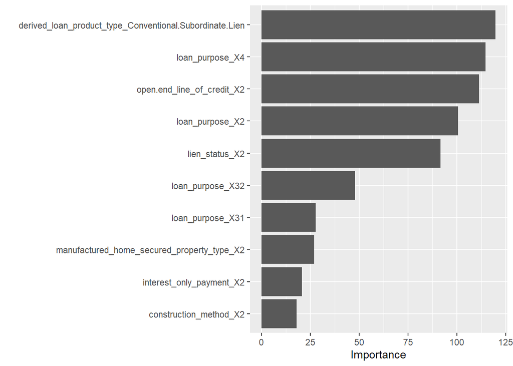

```r
#Variable importance plot
rfModel_fit |>
  extract_fit_parsnip() |>
  vip()
```

```r
# According to their importance, loan_purpose, open.end_line_of_credit, lien_status, and derived_loan_product_type are more important than others, I will use them to train our predictive model and discard other features.
feature_loan_categorical<-c("loan_purpose","open.end_line_of_credit","lien_status","derived_loan_product_type")

feature_discard <- c(feature_discard,c("derived_dwelling_category","conforming_loan_limit",
                                       "preapproval","loan_type","reverse_mortgage",
                                       "business_or_commercial_purpose",
                                       "negative_amortization",
                                       "interest_only_payment",
                                       "balloon_payment","other_nonamortizing_features",
                                       "construction_method",
                                       "occupancy_type",
                                       "manufactured_home_secured_property_type",
                                       "manufactured_home_land_property_interest"))
```

# Justification: In the next code block, I will explore categorical features relating to applicants’ privacy and then deal with their missing values. In the end I will discard some features have little impact on the prediction. Specific reasons are provided in the comments adjacent to the corresponding code.

```r
#These features indicate applicant's personal info.
privacy_data <- historical_data[,c(feature_privacy,target)]

#check the NA values
# the feature income and debt_to_income_ratio have NA values.
print(sum(is.na(privacy_data$derived_ethnicity)))
```

```
## [1] 0
```

```r
print(sum(is.na(privacy_data$derived_race)))
```

```
## [1] 0
```

```r
print(sum(is.na(privacy_data$derived_sex)))
```

```
## [1] 0
```

```r
print(sum(is.na(privacy_data$applicant_age)))
```

```
## [1] 0
```

```r
print(sum(is.na(privacy_data$co.applicant_age)))
```

```
## [1] 0
```

```r
print(sum(is.na(privacy_data$income))) #12470
```

```
## [1] 12470
```

```r
print(sum(is.na(privacy_data$debt_to_income_ratio))) #16927
```

```
## [1] 16927
```

```r
print(sum(is.na(privacy_data$applicant_credit_score_type)))
```

```
## [1] 0
```

```r
print(sum(is.na(privacy_data$co.applicant_credit_score_type)))
```

```
## [1] 0
```

```r
#These categorical features just contain only a few classes, which allow to apply random forest.
length(unique(privacy_data$derived_ethnicity))
```

```
## [1] 5
```

```r
length(unique(privacy_data$derived_race))
```

```
## [1] 6
```

```r
length(unique(privacy_data$derived_sex))
```

```
## [1] 4
```

```r
length(unique(privacy_data$applicant_age))
```

```
## [1] 8
```

```r
length(unique(privacy_data$co.applicant_age))
```

```
## [1] 9
```

```r
length(unique(privacy_data$applicant_credit_score_type))
```

```
## [1] 10
```

```r
length(unique(privacy_data$co.applicant_credit_score_type))
```

```
## [1] 11
```

```r
#From the description of debt_to_income_ratio in CFPB's website, it is the ratio of the applicant’s or borrower’s total monthly debt to the total monthly income. So I guess that debt_to_income_ratio = 100 * (loan_amount/loan_term) / (income/12)
historical_data[1:100,c("loan_amount","income","debt_to_income_ratio","loan_term")]
```

```
##     loan_amount income debt_to_income_ratio loan_term
## 1        165000    121                   39       360
## 2        265000    127                 <20%       360
## 3        205000     56                   44       360
## 4        595000    310             30%-<36%       360
## 5        285000    110                   46       360
## 6        165000     40                   37       360
## 7        275000    133                   42       360
## 8        215000     91             20%-<30%       360
## 9        205000    108             30%-<36%       180
## 10       185000     49                   40       360
## 11       405000    333                 <20%       240
## 12       285000    113             20%-<30%       360
## 13       295000     NA                 <20%       360
## 14       185000     60             30%-<36%       360
```

[output cut: 86 more lines]

```r
##but after observing the data, I found this formula does not hold. Nevertheless, I will generate a new column = 100 * (loan_amount/loan_term) / (income/12), and observe the relationship between this new column and debt_to_income_ratio.
debt_to_income_ratio_data <- historical_data[!is.na(historical_data$loan_term) &
                                             !is.na(historical_data$income) &
                                             !is.na(historical_data$debt_to_income_ratio) &
                                              historical_data$loan_term!="Exempt" &
                                              historical_data$income!=0 &
                                              historical_data$debt_to_income_ratio!="Exempt"
                                             ,c("loan_amount","loan_term",
                                                "income","debt_to_income_ratio")]

# convert debt_to_income_ratio to numerical values
debt_to_income_ratio_quantify <- function(value) {
  debt_to_income_ratio_value = 0
  if (is.na(value)){
    debt_to_income_ratio_value = -1 #for NA
  } else if (value == "<20%") {
    debt_to_income_ratio_value = 10 #using median as numerical value
  } else if (value=="20%-<30%") {
    debt_to_income_ratio_value = 25 #using median as numerical value
  } else if (value=="30%-<36%") {
    debt_to_income_ratio_value = 33 #using median as numerical value
  } else if (value=="37") {
    debt_to_income_ratio_value = 37
  } else if (value=="38") {
    debt_to_income_ratio_value = 38
  } else if (value=="39") {
    debt_to_income_ratio_value = 39
  } else if (value=="40") {
    debt_to_income_ratio_value = 40
  } else if (value=="41") {
    debt_to_income_ratio_value = 41
  } else if (value=="42") {
    debt_to_income_ratio_value = 42
  } else if (value=="43") {
    debt_to_income_ratio_value = 43
  } else if (value=="44") {
    debt_to_income_ratio_value = 44
  } else if (value=="45") {
    debt_to_income_ratio_value = 45
  } else if (value=="46") {
    debt_to_income_ratio_value = 46
  } else if (value=="47") {
    debt_to_income_ratio_value = 47
  } else if (value=="48") {
    debt_to_income_ratio_value = 48
  } else if (value=="49") {
    debt_to_income_ratio_value = 49
  } else if (value=="50%-60%") {
    debt_to_income_ratio_value = 55 #using median as numerical value
  } else if (value==">60%") {
    debt_to_income_ratio_value = 65 #Keeping the intervals equally spaced
  } else{
    debt_to_income_ratio_value = -1 # for Exempt
  }
  return(debt_to_income_ratio_value)
  }
#convert debt_to_income_ratio to numerical value
debt_to_income_ratio_data$debt_to_income_ratio_int <- sapply(debt_to_income_ratio_data$debt_to_income_ratio,
       debt_to_income_ratio_quantify)
#convert loan_term to numerical values
debt_to_income_ratio_data$loan_term <- as.integer(debt_to_income_ratio_data$loan_term)

#generate new_feature = (100 * loan_amount / loan_term) / (income / 12)
debt_to_income_ratio_data$new_feature <- (100 * debt_to_income_ratio_data$loan_amount / debt_to_income_ratio_data$loan_term) / (debt_to_income_ratio_data$income / 12)

#calculate the covariance between debt_to_income_ratio and new feature.
cor(debt_to_income_ratio_data$debt_to_income_ratio_int,debt_to_income_ratio_data$new_feature, use = "complete.obs")
```

```
## [1] 0.1281468
```

```r
#their covariance indicates that there does not exist obvious relationship between them. In this case, I will apply Mean imputation to deal with NA values in income and debt_to_income_ratio.
mean_income <- mean(privacy_data$income,na.rm = TRUE)
privacy_data$income <- ifelse(is.na(privacy_data$income),mean_income,privacy_data$income)
privacy_data$debt_to_income_ratio_int <- sapply(privacy_data$debt_to_income_ratio,
                                                debt_to_income_ratio_quantify)
mean_debt_to_income_ratio_int <- mean(privacy_data[privacy_data$debt_to_income_ratio_int!=-1,
                                                   c("debt_to_income_ratio_int")])
privacy_data$debt_to_income_ratio_int <- ifelse(privacy_data$debt_to_income_ratio_int == -1,
                                                mean_debt_to_income_ratio_int,
                                                privacy_data$debt_to_income_ratio_int)

#Use a logic regression model to inspect the importance of the these 2 features
privacy_regression_data <- privacy_data[,c("income",
                                                      "debt_to_income_ratio_int","action_taken")]
#scale these features
privacy_regression_data$income <- scale(privacy_regression_data$income)
privacy_regression_data$debt_to_income_ratio_int <- scale(privacy_regression_data$debt_to_income_ratio_int)

privacy_regression_data$action_taken<-ifelse(privacy_regression_data$action_taken == 1, 1, 0)
privacy_regression_data$action_taken<-as.factor(privacy_regression_data$action_taken)

#use the 10% of dataset to create training set and testing set
split <- initial_split(privacy_regression_data[sample(nrow(privacy_regression_data), size = 0.1 * nrow(privacy_regression_data)),], prop=0.80)

#Assign training instances to training_data
training_data <- training(split)

#Assign testing instances to testing_data
testing_data <- testing(split)

logisticModel <- logistic_reg(mode = "classification", engine = "glm")
logisticModel_fit <- logisticModel |>
fit(action_taken ~ ., data = training_data, family="binomial")
#This accuracy is acceptable.
testPred <- augment(logisticModel_fit, testing_data)
testPred |> accuracy(action_taken, .pred_class)
```

```
## # A tibble: 1 × 3
##   .metric  .estimator .estimate
##   <chr>    <chr>          <dbl>
## 1 accuracy binary         0.822
```

```r
#These two features have similar importance, I will use both of them to train our predictive model.
coef(logisticModel_fit$fit)
```

```
##              (Intercept)                   income debt_to_income_ratio_int
##                1.3703406                1.1207797               -0.7188397
```

```r
#convert debt_to_income_ratio to numerical value in historical_data
historical_data$debt_to_income_ratio_int <- sapply(historical_data$debt_to_income_ratio,
                                              debt_to_income_ratio_quantify)

mean_debt_to_income_ratio_int <- mean(historical_data[historical_data$debt_to_income_ratio_int!=-1,c("debt_to_income_ratio_int")])
historical_data$debt_to_income_ratio_int <- ifelse(historical_data$debt_to_income_ratio_int == -1,mean_debt_to_income_ratio_int,historical_data$debt_to_income_ratio_int)

#fill NA of income in historical_data
mean_income <- mean(historical_data$income,na.rm = TRUE)
historical_data$income <- ifelse(is.na(historical_data$income),mean_income,historical_data$income)

#Inspect the importance of other categorical privacy features using random forest.
privacy_rmf_data <- privacy_data[,c("derived_ethnicity","derived_race","derived_sex",
                                  "applicant_age","co.applicant_age",
                                  "applicant_credit_score_type",
                                  "co.applicant_credit_score_type","action_taken")]

privacy_rmf_data$derived_ethnicity <- as.factor(privacy_rmf_data$derived_ethnicity)
privacy_rmf_data$derived_race <- as.factor(privacy_rmf_data$derived_race)
privacy_rmf_data$derived_sex <- as.factor(privacy_rmf_data$derived_sex)
privacy_rmf_data$applicant_age <- as.factor(privacy_rmf_data$applicant_age)
privacy_rmf_data$co.applicant_age <- as.factor(privacy_rmf_data$co.applicant_age)
privacy_rmf_data$applicant_credit_score_type <- as.factor(privacy_rmf_data$applicant_credit_score_type)
privacy_rmf_data$co.applicant_credit_score_type <- as.factor(privacy_rmf_data$co.applicant_credit_score_type)
privacy_rmf_data$action_taken <- ifelse(privacy_rmf_data$action_taken == 1, 1, 0)
privacy_rmf_data$action_taken <- as.factor(privacy_rmf_data$action_taken)

#use the 10% of dataset to create training set and testing set
split <- initial_split(privacy_rmf_data[sample(nrow(privacy_rmf_data), size = 0.1 * nrow(privacy_rmf_data)),], prop=0.80)

#Assign training instances to training_data
training_data <- training(split)

#Assign testing instances to testing_data
testing_data <- testing(split)

privacy_recipe <- recipe(action_taken ~ .,
  data = training_data) |>
  # Convert categorical (nominal) features to dummy variables
  step_dummy(all_nominal_predictors())

rfModel <- rand_forest(mode = "classification",
  engine = "randomForest",
  mtry = 4,
  min_n = 100)

privacy_workflow <- workflow() |>
  add_model(rfModel) |>
  add_recipe(privacy_recipe)

rfModel_fit <- privacy_workflow |>
  fit(data = training_data)

#the accuracy is acceptable.
testPred <- augment(rfModel_fit, testing_data)
testPred |> accuracy(action_taken, .pred_class)
```

```
## # A tibble: 1 × 3
##   .metric  .estimator .estimate
##   <chr>    <chr>          <dbl>
## 1 accuracy binary         0.772
```

```r
# Variable importance table
rfModel_fit |>
  extract_fit_parsnip() |>
  vi()
```

```
## # A tibble: 46 × 2
##    Variable                               Importance
##    <chr>                                       <dbl>
##  1 applicant_credit_score_type_X8              113.
##  2 derived_race_Black.or.African.American       68.9
##  3 applicant_age_X25.34                         56.7
##  4 derived_race_White                           51.0
##  5 applicant_credit_score_type_X3               35.2
##  6 applicant_credit_score_type_X9               35.2
##  7 applicant_credit_score_type_X7               32.1
##  8 co.applicant_age_X9999                       28.9
##  9 derived_sex_Joint                            26.1
## 10 co.applicant_credit_score_type_X10           26.0
## # ℹ 36 more rows
```

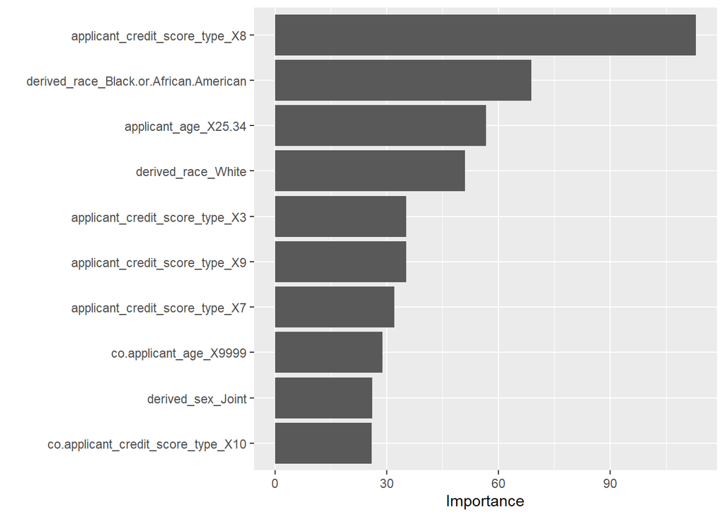

```r
# Variable importance plot
rfModel_fit |>
  extract_fit_parsnip() |>
  vip()
```

```r
#applicant_credit_score_type is the most important feature, I will use it to train our predictive model. Other features are much less important and can lead to some data ethical issues, so I will discard them.
feature_privacy <- c("income","debt_to_income_ratio_int","applicant_credit_score_type")
feature_discard <- c(feature_discard,c("derived_ethnicity","derived_race","derived_sex",
                                       "applicant_age","co.applicant_age",
                                       "co.applicant_credit_score_type",
                                       "debt_to_income_ratio"))
```

# Justification: Since I have already extracted the most relevant features from 5 dimensions (institution,district,underwriting system,loan information, and privacy), in the next code block, I will detect their outliers and discard those rows, resulting in a dataset for modeling.

```r
#We have already selected the features for training the model.
train_feature <- c(feature_financial,feature_area,feature_aus,feature_loan_numerical,
                   feature_loan_categorical,feature_privacy)

#Among all these train_features, some are numeric so that we need to deal with their outliers.
head(historical_data[,train_feature])
```

```
##   initially_payable_to_institution financial_institution_ratio_type area_pca_1
## 1                                2                                0 -0.5115918
## 2                                2                                0  0.3962549
## 3                                2                                0  0.2234786
## 4                                2                                0  1.6928499
## 5                                2                                0  6.4652832
## 6                                2                                0 -1.7705173
##   area_pca_2  area_pca_3 aus.1 loan_to_value_ratio_double loan_purpose
## 1 -0.7324451 -0.05290035     1                     90.000            1
## 2 -1.1277271  0.07867144     2                     80.000            1
## 3 -0.6927193  1.07593620     2                     97.000            1
## 4 -0.7957714  0.31818157     1                     80.000           31
## 5 -0.1635332  1.97007355     1                     98.188            1
## 6  0.1688304 -0.52414385     2                     95.000            1
##   open.end_line_of_credit lien_status derived_loan_product_type income
## 1                       2           1   Conventional:First Lien    121
## 2                       2           1   Conventional:First Lien    127
## 3                       2           1   Conventional:First Lien     56
## 4                       2           1   Conventional:First Lien    310
## 5                       2           1            FHA:First Lien    110
## 6                       2           1   Conventional:First Lien     40
##   debt_to_income_ratio_int applicant_credit_score_type
## 1                       39                           2
## 2                       10                           1
## 3                       44                           3
## 4                       33                           1
## 5                       46                           2
## 6                       37                           3
```

```r
#Due to a lack of domain knowledge, I was unable to discern whether certain data were outliers in district information related features because of input errors or sampling problems, or normal values that contained important information but were more special. As a result, I will only detect outliers in features relating to loan, property, and income based on common financial knowledge.
clean_numerical_feature<-c("loan_to_value_ratio_double",
                           "income",
                           "debt_to_income_ratio_int")

#I tried the DBSCAN to detect outliers, but it raised error:"std::bad_alloc", which is because the limitation of the computational resources of my laptop. So I will turn to  descriptive statistics.
summary(historical_data$loan_to_value_ratio_double)
```

```
##     Min.  1st Qu.   Median     Mean  3rd Qu.     Max.
##        0       68       80      116       95 12750000
```

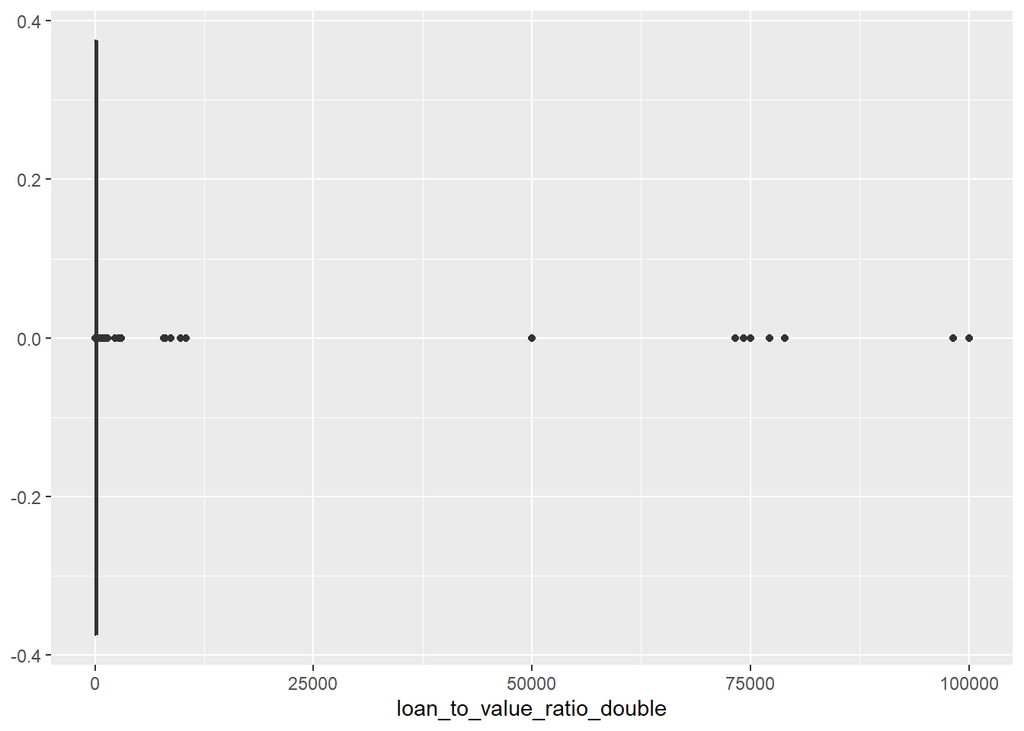

```r
#While I don't fully understand this feature, I still think that 0 and 12750000 does not make sense.
ggplot(historical_data[historical_data$loan_to_value_ratio_double > 0 & historical_data$loan_to_value_ratio_double<12750000,], aes(x=loan_to_value_ratio_double)) +
  geom_boxplot()
```

```r
#Apart from 0 and 12750000, there are still several errors. So I will apply traditional IQR methods to discard these error data.
Q1 <- quantile(historical_data$loan_to_value_ratio_double, 0.25)
Q3 <- quantile(historical_data$loan_to_value_ratio_double, 0.75)
LOWER_BOUND <- Q1 - 1.5 * (Q3 - Q1)
UPPER_BOUND <- Q3 + 1.5 * (Q3 - Q1)
loan_to_value_ratio_double_outliers <- which(historical_data$loan_to_value_ratio_double<LOWER_BOUND | historical_data$loan_to_value_ratio_double>UPPER_BOUND)

#this part of data is 5% of overall dataset. It has little impact on the model if discarding them.
length(loan_to_value_ratio_double_outliers) #17785
```

```
## [1] 17785
```

```r
#similarly, negative values and 365001 are impossible.
summary(historical_data$income)
```

```
##     Min.  1st Qu.   Median     Mean  3rd Qu.     Max.
##  -2414.0     51.0     81.0    108.6    120.0 365001.0
```

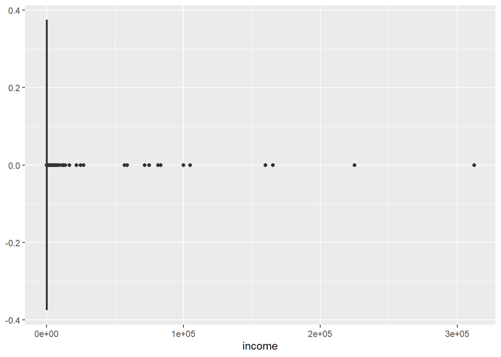

```r
ggplot(historical_data[historical_data$income > 0 & historical_data$income<365001,], aes(x=income)) +
  geom_boxplot()
```

```r
#use IQR method to deal with these data that significantly departs from the cluster.
q1 <- quantile(historical_data$income, 0.25)
q3 <- quantile(historical_data$income, 0.75)
LOWER_BOUND <- q1 - 1.5 * (q3 - q1)
UPPER_BOUND <- q3 + 1.5 * (q3 - q1)

#this part of data is 6% of overall dataset. #22152
income_outliers <- which(historical_data$income<LOWER_BOUND | historical_data$income>UPPER_BOUND)

#the data of debt_to_income_ratio seem to be more reasonable.
summary(historical_data$debt_to_income_ratio_int)
```

```
##    Min. 1st Qu.  Median    Mean 3rd Qu.    Max.
##    10.0    25.0    36.3    36.3    44.0    65.0
```

```r
#combine them to outliers indice
outliers <- union(income_outliers,loan_to_value_ratio_double_outliers)

#create and initialize dataset for modeling
model_data <- historical_data[-outliers,c(train_feature,target)]

#factorize the categorical data.
model_data$initially_payable_to_institution <- as.factor(model_data$initially_payable_to_institution)
model_data$financial_institution_ratio_type <- as.factor(model_data$financial_institution_ratio_type)
model_data$aus.1 <- as.factor(model_data$aus.1)
model_data$loan_purpose <- as.factor(model_data$loan_purpose)
model_data$open.end_line_of_credit <- as.factor(model_data$open.end_line_of_credit)
model_data$lien_status <- as.factor(model_data$lien_status)
model_data$derived_loan_product_type <- as.factor(model_data$derived_loan_product_type)
model_data$applicant_credit_score_type <- as.factor(model_data$applicant_credit_score_type)
model_data$action_taken <- ifelse(model_data$action_taken == 1, 1, 0)
model_data$action_taken <- as.factor(model_data$action_taken)
```

# Justification: In the last code block, I will train 2 models with XGboosting and bagging using selected features and cleaned data and finally choose one as the final predictive model based on their predictive accuracy.

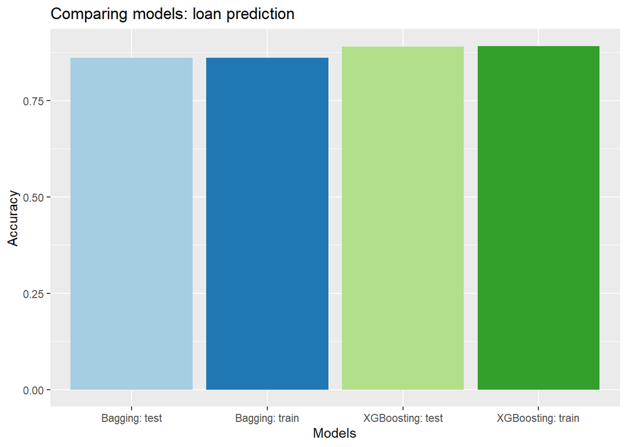

```r
split <- initial_split(model_data, prop=0.70)

# Assign training instances to training_data
training_data <- training(split)

# Assign testing instances to testing_data
testing_data <- testing(split)

#recipe
recipe <- recipe(action_taken ~ .,
  data = training_data) |>
  # Convert categorical (nominal) features to dummy variables
  step_dummy(all_nominal_predictors())

#XGboosting model
model_xgboost <- boost_tree(
  trees = 100,
  tree_depth = 6,
  learn_rate = 0.1,
  loss_reduction = 0.1,
  mtry = 6,
  min_n = 50,
  mode = "classification",
  engine = "xgboost"
)

#fit XGboosting model with train data
xgb_fit <- workflow() |>
  add_recipe(recipe) |>
  add_model(model_xgboost) |>
  fit(data = training_data)

#Add predictions and class probabilities to training and testing data
training_xgb <- augment(xgb_fit, training_data)
testing_xgb <- augment(xgb_fit, testing_data)

#bagging modeling
model_bagging <- bag_tree(
  tree_depth = 6,
  min_n = 50,
  mode = "classification"
)

#fit bagging model with train data
bagging_fit <- workflow() |>
  add_recipe(recipe) |>
  add_model(model_bagging) |>
  fit(data = training_data)

#Add predictions and class probabilities to training and testing data
training_bagging <- augment(bagging_fit, training_data)
testing_bagging <- augment(bagging_fit, testing_data)

#Save scores from XGboosting and bagging models
scores <- c(
  metrics(training_xgb, action_taken, .pred_class)$.estimate[1],
  metrics(testing_xgb, action_taken, .pred_class)$.estimate[1],
  metrics(training_bagging, action_taken, .pred_class)$.estimate[1],
  metrics(testing_bagging, action_taken, .pred_class)$.estimate[1])

#Combine into dataframe
results <- data.frame(scores = scores, models = c("XGBoosting: train", "XGBoosting: test", "Bagging: train", "Bagging: test"))

#Plot results
results |>
  ggplot(aes(x = models, y = scores)) +
  geom_col(aes(fill = models)) +
  scale_fill_brewer(palette = "Paired") +
  labs(x = "Models", y = "Accuracy", title = "Comparing models: loan prediction") +
  theme(legend.position = "none")
```

```r
results[,c("models","scores")]
```

```
##              models    scores
## 1 XGBoosting: train 0.8916925
## 2  XGBoosting: test 0.8903779
## 3    Bagging: train 0.8611791
## 4     Bagging: test 0.8606370
```

```r
#Comparing the accuracy of two models, I will choose the model_xgboost as my final model to predict loan repayment, since it has a higher prediction accuracy.
binary_model <- model_xgboost
```

# Addendum: Due to constraints in domain knowledge and the computational limitations of my laptop, I streamlined certain steps in feature engineering and model selection. In future projects, I anticipate improvements through collaboration with domain experts and leveraging cloud computing services.